# Organizing a Data Analysis

## Data analysis files

- Data
- Raw data
- Processed data
- Figures
- Exploratory figures
- Final figures
- R code
- Raw / unused scripts
- Final scripts
- R Markdown files
- Text
- README files
- Text of analysis / report

## Raw Data

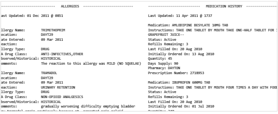

- Should be stored in your analysis folder
- If accessed from the web, include url, description, and date accessed in README

## Processed data

[figure not shown]

* Processed data should be named so it is easy to see which script generated the data. * The processing script - processed data mapping should occur in the README * Processed data should be [tidy](http://vita.had.co.nz/papers/tidy-data.pdf)

## Exploratory figures

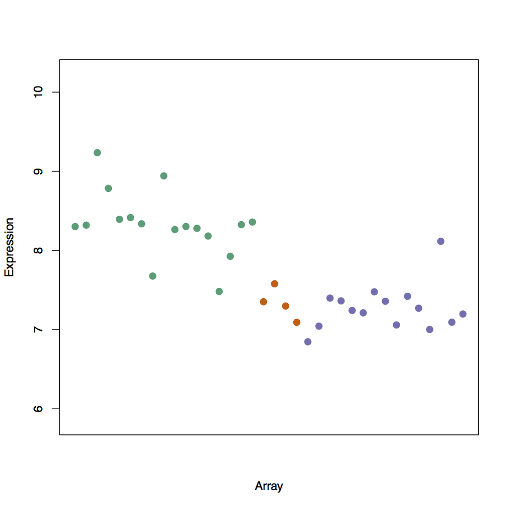

- Figures made during the course of your analysis, not necessarily part of your final report.
- They do not need to be "pretty"

## Final Figures

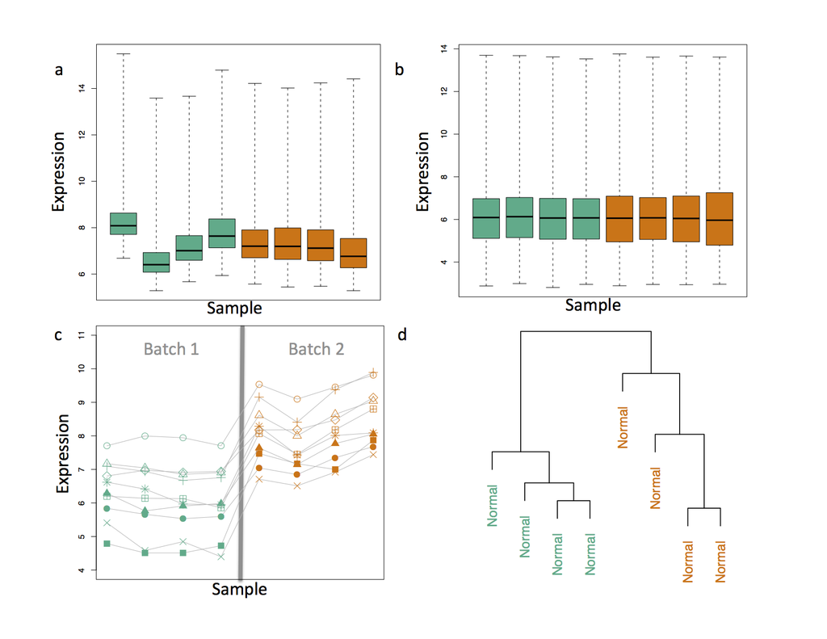

- Usually a small subset of the original figures
- Axes/colors set to make the figure clear
- Possibly multiple panels

## Raw scripts

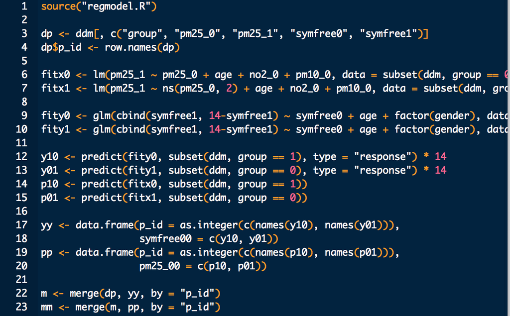

- May be less commented (but comments help you!)
- May be multiple versions
- May include analyses that are later discarded

## Final scripts

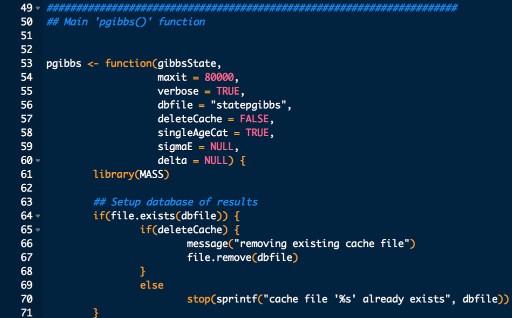

- Clearly commented
- Small comments liberally - what, when, why, how
- Bigger commented blocks for whole sections
- Include processing details
- Only analyses that appear in the final write-up

## R markdown files

[figure not shown]

- [R markdown](http://www.rstudio.com/ide/docs/authoring/using_markdown) files can be used to generate reproducible reports
- Text and R code are integrated
- Very easy to create in [Rstudio](http://www.rstudio.com/)

## Readme files

[figure not shown]

- Not necessary if you use R markdown
- Should contain step-by-step instructions for analysis
- Here is an example https://github.com/jtleek/swfdr/blob/master/README.md

## Text of the document

[figure not shown]

- It should include a title, introduction (motivation), methods (statistics you used), results (including measures of uncertainty), and conclusions (including potential problems)
- It should tell a story
- *It should not include every analysis you performed*
- References should be included for statistical methods

## Further resources

- Information about a non-reproducible study that led to cancer patients being mistreated: [The Duke Saga Starter Set](http://simplystatistics.org/2012/02/27/the-duke-saga-starter-set/)
- [Reproducible research and Biostatistics](http://biostatistics.oxfordjournals.org/content/10/3/405.full)
- [Managing a statistical analysis project guidelines and best practices](http://www.r-statistics.com/2010/09/managing-a-statistical-analysis-project-guidelines-and-best-practices/)
- [Project template](http://projecttemplate.net/) - a pre-organized set of files for data analysis